# Ozone Research

Emily McCarthy

(February 17, 2020)

## Introduction

This notebook is my first attempt at working with R after not doing it for a loooooonngggg time so here we go! If successful, this notebook will analyze how air quality changes over time in STL and SLC.

## Dependencies

```r
# tidyverse packages
library(dplyr)
library(stringr)
library(tibble)
library(readr)
library(tidyr)
library(leaflet)
library(mapview)

# other packages
library(here)
library(sf)
library(janitor)
library(naniar)
```

## Load Data

```r
ozoneMo <- read_csv(here("data", "Ozone_2015.csv"))
ozone2012 <- read_csv(here("data", "Ozone_2012.csv"))
ozoneIL <- read_csv(here("data", "ILL_ozone_2015.csv"))
ozoneMad <- read_csv(here("data", "madison_ozone.csv"))
```

## Part 1

### Online Resources

- 9/18/2019:

Sources used to find information about AQI and the ozone.

0-300 SCALE

0-50 Safe

50-100 Moderate for sensitive groups

100-150 Unhealthy for sensitive groups

151+ Unhealthy for all groups

https://ephtn.dhss.mo.gov/EPHTN_Data_Portal/airquality/pdf/aqibrochure.pdf https://ephtn.dhss.mo.gov/EPHTN_Data_Portal/airquality/index.php https://www3.epa.gov/aircompare/

### Data Cleaning

```r
ozoneMo %>%
  clean_names(case = "snake") -> ozoneMo

ozone2012 %>%
  clean_names(case = "snake") -> ozone2012
```

I will be subsetting the data in ozoneMO and ozone2012 so that only Metro West counties are included in these data.

```r
ozoneMetro <- ozoneMo[which(ozoneMo$county_code == c(510, 189, 99, 183)),names(ozoneMo) %in% c("county_code", "site_num", "latitude", "longitude", "county_name", "date_local","aqi", "observation_count", "observation_percent", "x1st_max_value")]
```

```
longer object length is not a multiple of shorter object length
```

```r
ozoneMo %>%
  filter('County Name' %in% c("St. Louis City", "Saint Louis", "Saint Charles", "Jefferson")) -> ozoneTest
```

- 10/01/2019:

I am now going to create geometry in the STL data set.

```r
metro_sf <- st_as_sf(ozoneMetro, coords = c(x = "longitude", y = "latitude"), crs = 4269)
```

With this I will use leaflet to create a mapview map below

```r
mapview(metro_sf)
```

[interactive chart not shown]

it didnt work!

Now I will repeat this process with 2012 ozone data.

```r
#ozone_metro2012 <- ozone2012[which(ozone2012$county_code == c(510, 189, 99, 183)),names(ozone2012) #%in% c("county_code", "aqs_site_id", "site_latitude", "site_longitude", "county", #"date","daily_aqi_value", "daily_obs_count", "daily_max_8_hour_ozone_concentration")]
```

```r
#sf2012 <- st_as_sf(ozone_metro2012, coords = c(x = "site_longitude", y = "site_latitude"), crs = 4269)
```

Preview of locations from 2012 dataset

```r
#mapview(sf2012)
```

- 10/13/2019:

EPA air quality open data: https://aqs.epa.gov/// https://www.epa.gov/outdoor-air-quality-data Global open data index: https://index.okfn.org/

I will be mapping the location of the AQI station in Metro-East.

```r
#ozoneILsf <-st_as_sf(ozoneIL, coords = c(x = "SITE_LONGITUDE", y = "SITE_LATITUDE"), crs = 4269)
```

```r
#mapview(ozoneILsf)
```

May be a useful station to include for analysis of south city.

Counties to look for: Madison, Monroe Create a single sf object with all station locations use rbind(x,y) –> write to a shapefile A description of the results.

- 10/29/2019:

```r
#ozoneMadSf <-st_as_sf(ozoneMad, coords = c(x = "SITE_LONGITUDE", y = "SITE_LATITUDE"), crs = 4269)
#mapview(ozoneMadSf)
```

I am unable to find data for Monroe county.

I will now bind these locations to create one shapefile with locations.

```r
#Ometro_sf <- rbind(ozoneMadSf, ozoneILsf, deparse.level = 1)
#mapview(Ometro_sf)
```

I will now continue to combine data sets beause I can bind two data frames at a time.

```r
#Ometro_sf <- clean_names(Ometro_sf, case = "snake")
```

```r
metro_sf <- select(metro_sf, "county_code", "county_name", "date_local", "observation_count", "observation_percent", "site_num", "aqi", "geometry")
```

```r
#Ometro_sf %>%
  rename(county_name = county,
  date_local = date,
  aqi = daily_aqi_value,
  observation_count = daily_obs_count,
  observation_percent = percent_complete,
  x1st_max_value = daily_max_8_hour_ozone_concentration
) -> Ometro_names
```

```r
#STLareaSF <- rbind(Ometro_names, metro_sf, deparse.level = 1)
mapview(metro_sf)
```

- make shapefile of just locations
- share .shp zip w/ Prener

```r
# saving shapefile
st_write(metro_sf, dsn = here("data", "stlmetrolocations.shp"), delete_dsn = TRUE)
```

- replace Ava’s athsma data comparisions with redlining comparisons
- summarize 50 words the relationship between redlining and comtemporary demographic %black/%poverty

```r
metro_sf %>%
  filter(metro_sf$aqi >= 50) %>%
  group_by(site_num) %>%
  summarise(count = n()) -> unhealthy15
```

## Part 2

Literally doing the exact same thing as above except for 2010-2014

loading data

```r
o2014 <- read_csv(here("data", "O_2014.csv"))
o2013 <- read_csv(here("data", "O_2013.csv"))
o2012 <- read_csv(here("data", "O_2012.csv"))
o2011 <- read_csv(here("data", "O_2011.csv"))
o2010 <- read_csv(here("data", "O_2010.csv"))
```

2014 sorting of necessary MO counties

```r
o2014 %>%
  clean_names(case = "snake") %>%
  filter(o2014$COUNTY_CODE == c(510, 189, 99, 183)) -> o2014
```

```r
select(o2014, "date", "aqs_site_id", "daily_aqi_value", "county_code", "county", "site_latitude", "site_longitude") -> o2014
```

2013 ’’

```r
o2013 %>%
  clean_names(case = "snake") %>%
  filter(o2013$COUNTY_CODE == c(510, 189, 99, 183)) -> o2013
```

```r
select(o2013, "date", "daily_aqi_value", "county_code", "county", "site_latitude", "site_longitude", "aqs_site_id",) -> o2013
```

2012 ’’

```r
o2012 %>%
  clean_names(case = "snake") %>%
  filter(o2012$COUNTY_CODE == c(510, 189, 099, 183)) -> o2012
```

```r
select(o2012, "date", "daily_aqi_value", "county_code", "county", "site_latitude", "site_longitude", "aqs_site_id",) -> o2012
```

2011 ’’

```r
o2011 %>%
  clean_names(case = "snake") %>%
  filter(o2011$COUNTY_CODE == c(510, 189, 099, 183)) -> o2011
```

```r
select(o2011, "date", "daily_aqi_value", "county_code", "county", "site_latitude", "site_longitude", "aqs_site_id") -> o2011
```

2010 ’’

```r
o2010 %>%
  clean_names(case = "snake") %>%
  filter(o2010$COUNTY_CODE == c(510, 189, 099, 183)) -> o2010
```

```r
select(o2010, "sample_date", "daily_aqi_value", "county_code", "county", "latitude", "longitude", "aqs_site_id") -> o2010
```

Repeating the process for illinois – reading data

```r
il2014 <- read_csv(here("data", "il2014.csv"))
il2013 <- read_csv(here("data", "il2013.csv"))
il2012 <- read_csv(here("data", "il2012.csv"))
il2011 <- read_csv(here("data", "il2011.csv"))
il2010 <- read_csv(here("data", "il2010.csv"))
```

selecting Madison and Saint Clair county

```r
il2014 %>%
  clean_names(case = "snake") %>%
  filter(il2014$COUNTY_CODE == c(119, 163)) -> il2014

il2013 %>%
  clean_names(case = "snake") %>%
  filter(il2013$COUNTY_CODE == c(119, 163)) -> il2013

il2012 %>%
  clean_names(case = "snake") %>%
  filter(il2012$COUNTY_CODE == c(119, 163)) -> il2012

il2011 %>%
  clean_names(case = "snake") %>%
  filter(il2011$COUNTY_CODE == c(119, 163)) -> il2011

il2010 %>%
  clean_names(case = "snake") %>%
  filter(il2010$COUNTY_CODE == c(119, 163)) -> il2010
```

```r
select(il2014, "date", "daily_aqi_value", "county_code", "county", "site_latitude", "site_longitude", "site_id") -> il2014
select(il2013, "date", "daily_aqi_value", "county_code", "county", "site_latitude", "site_longitude", "site_id") -> il2013
select(il2012, "date", "daily_aqi_value", "county_code", "county", "site_latitude", "site_longitude", "site_id") -> il2012
select(il2011, "date", "daily_aqi_value", "county_code", "county", "site_latitude", "site_longitude", "site_id") -> il2011
select(il2010, "date", "daily_aqi_value", "county_code", "county", "site_latitude", "site_longitude", "site_id") -> il2010
```

Renaming “site_id” to “aqs_site_id” to bind tables

```r
il2014 %>%
  rename(aqs_site_id = site_id) -> il2014
il2013 %>%
  rename(aqs_site_id = site_id) -> il2013
il2012 %>%
  rename(aqs_site_id = site_id) -> il2012
il2011 %>%
  rename(aqs_site_id = site_id) -> il2011
il2010 %>%
  rename(aqs_site_id = site_id) -> il2010
```

Renaming o2010 columns

```r
o2010 %>%
  rename(date = sample_date,
         site_latitude = latitude,
         site_longitude = longitude) -> o2010
```

Joining illinois and missouri data

```r
o2014 %>%
rbind(o2014, il2014, deparse.level = 1) -> il2014

o2013 %>%
rbind(o2013, il2013, deparse.level = 1) -> il2013

o2012 %>%
rbind(o2012, il2012, deparse.level = 1) -> il2012

o2011 %>%
rbind(o2011, il2011, deparse.level = 1) -> il2011

o2010 %>%
  rbind(o2010, il2010, desparse.level = 1) -> il2010
```

```r
st_as_sf(o2014, coords = c(x = "site_longitude", y = "site_latitude"), crs = 4269) -> o2014
st_as_sf(o2013, coords = c(x = "site_longitude", y = "site_latitude"), crs = 4269) -> o2013
st_as_sf(o2012, coords = c(x = "site_longitude", y = "site_latitude"), crs = 4269) -> o2012
st_as_sf(o2011, coords = c(x = "site_longitude", y = "site_latitude"), crs = 4269) -> o2011
```

```r
st_as_sf(o2010, coords = c(x = "site_longitude", y = "site_latitude"), crs = 4269) -> o2010
```

creating count of unhealthy groups

```r
o2014 %>%
  filter(o2014$daily_aqi_value >= 50) %>%
  group_by(aqs_site_id) %>%
  summarise(count = n()) -> unhealthy14

o2013 %>%
  filter(o2013$daily_aqi_value >= 50) %>%
  group_by(aqs_site_id) %>%
  summarise(count = n()) -> unhealthy13

o2012 %>%
  filter(o2012$daily_aqi_value >= 50) %>%
  group_by(aqs_site_id) %>%
  summarise(count = n()) -> unhealthy12

o2011 %>%
  filter(o2011$daily_aqi_value >= 50) %>%
  group_by(aqs_site_id) %>%
  summarise(count = n()) -> unhealthy11

o2010 %>%
  filter(o2010$daily_aqi_value >= 50) %>%
  group_by(aqs_site_id) %>%
  summarise(count = n()) -> unhealthy10
```

## Part 3: Kriging

```r
library(rspatial)
```

```r
as_Spatial(unhealthy15)
```

```r
library(gstat)
gs <- gstat(formula=count~1, locations=unhealthy15)
v <- variogram(gs, width=20)
head(v)
plot(v)
```

Getting stuck on code below

```r
fve <- fit.variogram(v, vgm(85, "Exp", 75, 20))
fve
plot(variogramLine(fve, 400), type='l', ylim=c(0,120))
points(v[,2:3], pch=20, col='red')
```

#### Pre-SP CONVERSION

```r
as_Spatial(unhealthy15)
```

```r
mutate(unhealthy15, count = as.numeric(count), site_num = as.numeric(site_num)) -> unhealthy15n
```

```r
library(rspatial)
unhealthy15n$prec <- plot(sort(unhealthy15n$prec), ylab='Unhealthy Days', las=1, xlab='site_num')
```

```r
library(rspatial)
x <- sp_data("airqual")
x$OZDLYAV <- x$OZDLYAV * 1000
```

```r
library(gstat)
gs <- gstat(formula=OZDLYAV~1, locations=unhealthy15n)
v <- variogram(gs, width=20)
head(v)
plot(v)
```

```r
library(sp)
library(gstat)
gs <- gstat(formula=prec~1, locations=unhealthy15n, nmax=5, set=list(idp = 0))
nn <- interpolate(r, gs)
## [inverse distance weighted interpolation]
nnmsk <- mask(nn, vr)
plot(nnmsk)
```

```r
#Variogram from R pdf
library(gstat)
lzn.vgm = variogram(log(count)~1, unhealthy15n)
lzn.vgm
```

```r
lzn.fit = fit.variogram(lzn.vgm, model = vgm(1, "Sph", 900, 1))
lzn.fit
```

```r
plot(lzn.vgm, lzn.fit)
```

```r
#lznr.vgm = variogram(log(count)~sqrt(dist), unhealthy15n)
data(unhealthy15n.grid)
```

```r
library(stars)
lzn.kriged = krige(log(count)~1, unhealthy15n, unhealthy15n, model = lzn.fit)
```

```r
library(sp)
spplot(lzn.kriged["var1.pred"])
```

```r
lzn.idw = idw(count~1, unhealthy15n, unhealthy15n)
spplot(lzn.idw["var1.pred"], main = "u15 idw")
```

- Small multiples on right side and metro map with estimated air values
- Left demographic data
- Center textboxes

## Plotting

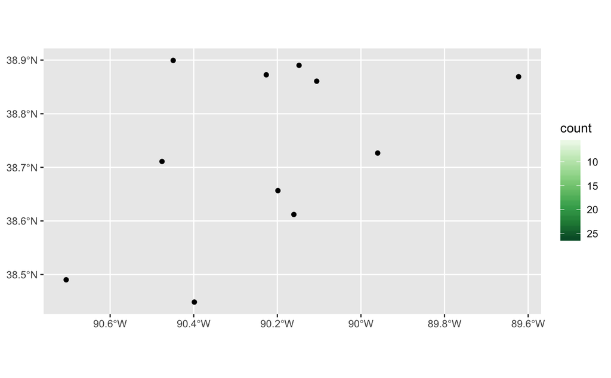

```r
ggplot() +
    geom_sf(data = unhealthy14, mapping = aes(fill = count)) +
  scale_fill_distiller(palette = "Greens", trans ="reverse")
```